# Análise e visualização de dados espaciais com R - 2a. Parte

Walter Humberto Subiza Piña

2018-08-25

### Indice

#### 1. Leitura de arquivos vetoriais e *raster*

Exercicio 02

a- Ponto

b- Linha

c- Poligono

d- Multipoligono

Exercício 03

e- *raster* com uma camada ou layer

f- *raster* multi-camadas ou multilayers

g- Base de dados *PostGis*

#### 2- Manipulação de dados georreferenciados

a- Extração de metadados

b- Identificação ou definição do *CRS*

Exercício 04

c- Reprojetar ou transformar um objeto georreferenciado

Exercício 05

d- conversão de dataframe com coordenadas em objeto `sf`, e viceversa

Exercício 06

Exercício 07

Exercício 08

e- outras funções de geoprocessamento

Os dados para reproduzir os exercicios encontram-se na pasta “/data” e devem ser baixados de [*dropbox*](https://www.dropbox.com/sh/2gmhfx1ycos0ywh/AAAjVB6T6oygAq6nmFQEMUMNa?dl=0). A pasta completa deve estar no seu diretorio de trabalho.

As seguintes bibliotecas do *R* devem estar instaladas e carregadas para a correta execução dos fragmentos de código.

```r
library(sf)
library(raster)
library(tidyverse)
```

### 1- Leitura de arquivos vetoriais e raster

A leitura de arquivos vetoriais (ponto, linha ou polígono) usando o pacote `sf` é simples. A função `st_read()` determina automáticamente o formato adequado de importação quando colocamos o caminho e nome do arquivo com a extensão do mesmo. A função é capaz de ler um dado vetorial ou diretamente uma tabela *PostGis*. A mensagem na tela que resulta da execução desta função pode ser suprimida, usando o argumento `quit = T`, ou usando diretamente a função `read_sf()`.

As funções mencionadas fazem uso da biblioteca `Geospatial Data Abstraction Library` ([GDAL](http://www.gdal.org/)) implantada no *R* através de `rgdal`, o que permite que sejam importados mais de 200 formatos diferentes de arquivos.

No caso de arquivos tipo *shape* ou camada, os arquivos necessários para uma correta importação são, ao mínimo, três com extensões: “.shp”, “.dbf” e “.shx”. Um quarto arquivo com extensão “.prj”, contendo o *CRS* pode estar presente ou ser omitido.

#### Exercicio 02

Na sequência apresentam-se quatro importações de arquivos vetoriais com geometria de ponto, linha, poligono e multipoligono.

Em cada importação feita, analise a saída e identifique:

- o tipo de geometria,
- a quantidade de registros e atributos, e
- o *CRS*

#### a- Ponto

```r
# leitura de arquivo vetorial de pontos
nig_pts <- st_read("data/nova_iguacu_pontos.shp")
# verificamos a classe do objeto
class(nig_pts)
```

```
## [1] "sf"         "data.frame"
```

```r
# primeiras duas linhas do objeto
head(nig_pts,2)
```

```
## Simple feature collection with 2 features and 11 fields
## geometry type:  POINT
## dimension:      XYZ
## bbox:           xmin: -43.60834 ymin: -22.82786 xmax: -43.60747 ymax: -22.8277
## epsg (SRID):    4326
## proj4string:    +proj=longlat +datum=WGS84 +no_defs
##                        Name descriptio timestamp begin  end altitudeMo
## 1                  ciep-167       <NA>      <NA>  <NA> <NA>       <NA>
## 2 Prefeitura de Nova Iguacu       <NA>      <NA>  <NA> <NA>       <NA>
##   tessellate extrude visibility drawOrder icon
## 1         -1       0         -1        NA <NA>
## 2         -1       0         -1        NA <NA>
##                         geometry
## 1 POINT Z (-43.60747 -22.8277 0)
## 2 POINT Z (-43.60834 -22.8278...
```

Aproveitando que o objeto criado é da classe S-3 e é tratado como dataframe, vamos eliminar as colunas desnecessárias usando a função `select()` e deixando apenas o nome (variável “Name”). Note o fato de que a geometria esta preservada apesar da eliminação de atributos realizada após o `select`.

```r
nig_pts <- nig_pts %>%
  select(Name)

head(nig_pts,4)
```

```
## Simple feature collection with 4 features and 1 field
## geometry type:  POINT
## dimension:      XYZ
## bbox:           xmin: -43.61354 ymin: -22.82786 xmax: -43.59195 ymax: -22.82065
## epsg (SRID):    4326
## proj4string:    +proj=longlat +datum=WGS84 +no_defs
##                        Name                       geometry
## 1                  ciep-167 POINT Z (-43.60747 -22.8277 0)
## 2 Prefeitura de Nova Iguacu POINT Z (-43.60834 -22.8278...
## 3            Jardim Paraiso POINT Z (-43.59195 -22.8209...
## 4             Jardim Guandu POINT Z (-43.61354 -22.8206...
```

#### b- Linha

```r
# leitura de arquivo vetorial de linhas
nig_lin <- st_read("data/nova_iguacu_linha.shp")
# verificamos a classe do objeto
class(nig_lin)
```

```
## [1] "sf"         "data.frame"
```

```r
# primeiras linhas do objeto
head(nig_lin)
```

```
## Simple feature collection with 2 features and 1 field
## geometry type:  LINESTRING
## dimension:      XY
## bbox:           xmin: -43.61543 ymin: -22.83208 xmax: -43.48624 ymax: -22.74275
## epsg (SRID):    4326
## proj4string:    +proj=longlat +datum=WGS84 +no_defs
##   id                       geometry
## 1  1 LINESTRING (-43.61543 -22.8...
## 2  2 LINESTRING (-43.48624 -22.7...
```

#### c- Poligono

Na leitura de arquivos vetoriais com variáveis gravadas em outros idiomas que o inglês, devemos especificar o tipo de código usado na criação do arquivo, a fim de preservar os carateres especiais presentes nos atributos. Se o arquivo provem de um GIS, basta verificar nas propriedades da exportação. Se a codificação é desconhecida, devemos encontrar a correta, testando diversas opções. As mais usadas são “UTF-8”, “windows-1252”, “latin1” ou “system”. Veja no exemplo o uso da codificação *UTF-8*.

```r
# leitura de arquivo vetorial com 1 poligono e codificação UTF-8
nig_pol <- st_read("data/nova_ig_mun_UTF.shp", options = "ENCODING=UTF-8")
```

```
## options:        ENCODING=UTF-8
```

```r
# Inspeção do dataframe sf
nig_pol
```

```
## Simple feature collection with 1 feature and 3 fields
## geometry type:  POLYGON
## dimension:      XYZ
## bbox:           xmin: -43.67405 ymin: -22.86524 xmax: -43.36491 ymax: -22.52698
## epsg (SRID):    NA
## proj4string:    +proj=longlat +ellps=GRS80 +no_defs
##     ID CD_GEOCODM  NM_MUNICIP                       geometry
## 1 1517    3303500 NOVA IGUAÇU POLYGON Z ((-43.56948 -22.6...
```

Na importação efetuada, qual o *CRS* e o tipo de geometria? Que informação temos no dataframe?

#### d- Multipoligono

```r
# leitura de arquivo  vetorial multipoligono, codificado UTF-8
rj_mun <- st_read("data/RJ_municip.shp", options = "ENCODING=UTF-8" )
```

```
## options:        ENCODING=UTF-8
```

```r
# Inspeção do dataframe sf (apenas 6 registros)
head(rj_mun)
```

```
## Simple feature collection with 6 features and 3 fields
## geometry type:  MULTIPOLYGON
## dimension:      XYZ
## bbox:           xmin: -44.64041 ymin: -23.22668 xmax: -41.86353 ymax: -21.60126
## epsg (SRID):    NA
## proj4string:    +proj=longlat +ellps=GRS80 +no_defs
##     ID CD_GEOCODM         NM_MUNICIP                       geometry
## 1 1468    3300100     ANGRA DOS REIS MULTIPOLYGON Z (((-44.33208...
## 2 1469    3300159            APERIBÉ MULTIPOLYGON Z (((-42.0895 ...
## 3 1470    3300209           ARARUAMA MULTIPOLYGON Z (((-42.22526...
## 4 1471    3300225              AREAL MULTIPOLYGON Z (((-43.16007...
## 5 1472    3300233 ARMAÇÃO DOS BÚZIOS MULTIPOLYGON Z (((-41.98427...
## 6 1473    3300258    ARRAIAL DO CABO MULTIPOLYGON Z (((-42.00496...
```

Identifique a extensão geográfica do arquivo e o *CRS*.

#### e- Raster com uma camada ou *layer*

Na leitura de arquivos tipo matricial ou *raster*, usamos o pacote e função `raster::raster`. A importação é semelhante à vetorial e apenas especificam-se o caminho, nome e extensão do arquivo. No caso de dados com apenas uma camada de informação, a importação vai gerar um objeto da classe `RasterLayer`.

No seguinte fragmento de código importamos um arquivo proveniente de imagens de fotografias aéreas do Rio de Janeiro. Primero importamos o modelo digital de elevações - MDE (uma banda) e na sequência uma ortofoto digital de três bandas, na combinação vermelho, verde e azul (RGB), usando a função `brick`.

#### Exercício 03

```r
(nig_MDE <- raster("data/MDE_27444ne_v1.tif"))
```

```
## class       : RasterLayer
## dimensions  : 752, 699, 525648  (nrow, ncol, ncell)
## resolution  : 20, 20  (x, y)
## extent      : 640552.8, 654532.8, 7468992, 7484032  (xmin, xmax, ymin, ymax)
## coord. ref. : +proj=utm +zone=23 +south +datum=WGS84 +units=m +no_defs +ellps=WGS84 +towgs84=0,0,0
## data source : C:\Users\Walter Pina\Documents\Github\Intro_analise_espacial_R\data\MDE_27444ne_v1.tif
## names       : MDE_27444ne_v1
## values      : -32768, 32767  (min, max)
```

```r
class(nig_MDE)
```

```
## [1] "RasterLayer"
## attr(,"package")
## [1] "raster"
```

Identifique a extensão geográfica do arquivo, seu tamanho e o *CRS*. Quantas camadas o compõem?

#### f- raster multi-camadas ou *multilayers*, funções `brick` e`stack()`

Importamos uma ortofoto, neste caso, o objeto criado será da classe `RasterBrick`.

```r
nig_orto <- brick("data/27444ne.tif")
class(nig_orto)
```

```
## [1] "RasterBrick"
## attr(,"package")
## [1] "raster"
```

```r
nig_orto
```

```
## class       : RasterBrick
## dimensions  : 14611, 13598, 198680378, 3  (nrow, ncol, ncell, nlayers)
## resolution  : 1, 1  (x, y)
## extent      : 640726, 654324, 7469341, 7483952  (xmin, xmax, ymin, ymax)
## coord. ref. : +proj=utm +zone=23 +south +ellps=GRS80 +towgs84=0,0,0,0,0,0,0 +units=m +no_defs
## data source : C:\Users\Walter Pina\Documents\Github\Intro_analise_espacial_R\data\27444ne.tif
## names       : X27444ne.1, X27444ne.2, X27444ne.3
## min values  :          0,          0,          0
## max values  :        255,        255,        255
```

Identifique a extensão geográfica do arquivo, seu tamanho e o *CRS*. Quantas camadas o compõem, onde está essa informação?

É importante lembrar que na leitura destes arquivos, as funções `raster` e `brick` não carregam na memória do computador os valores das células. Os arquivos raster podem ser de grande tamanho e a fim de convervar a memória, os dados são efetivamente lidos quando são requeridos.

No seguinte código, vemos o tamanho de um arquivo raster em memória e em disco.

```r
# em memória:
object.size(nig_orto)
```

```
## 13320 bytes
```

```r
# em disco:
file.size("data/27444ne.tif")
```

```
## [1] 596158448
```

Uma outra função, `stack()` cria objetos *raster* multicamadas. Neste caso podemos juntar diversas camadas de um mesmo objeto ou objetos diferentes, mas é necessário que as diversas camadas estejan **no mesmo CRS e com a mesma resolução espacial**.  
—

#### g- Base de dados *PostGis*

A importação de tabelas de bases de dados *PostGis* é relativamente simples, com tanto que se tenham as informações de acesso requeridas pela base. Até o momento, esse método está implementado apenas em servidores PostGis.

Os seguintes argumentos são necessários:

- **dbname**: o nome da base de dados PostGis
- **host**: endereço da base de dados, se é a máquina local ‘localhost’
- **port**: porta de acesso, o padrão para máquina local é ‘5432’
- **user**: nome do usuário, ele deve estar previamente cadastrado na base de dados
- **password**: a senha correspondente ao usuário cadastrado

As informações podem ser inseridas diretamente na função `st_read()` ou pode ser criado uma conexão para depois efetuar o chamado.

Exemplo criando uma conexão:

```
conn <- "PG:dbname='ibgebases' host='localhost' port='5432' user='Beto' password='MinhaSenha'"
```

o código “PG:” indica que é uma base *PostGis*, na sequência faço a leitura da base de dados:

```
minha_tabela <- st_read(conn)
```

Se todas as configurações estão corretas, acontecerá um dos seguintes casos:

1- Não existindo nenhuma tabela na base de dados, será emitida uma **mensagem de erro**;

2- Se a base de dados tiver apenas uma tabela, ela será lida e importada como o objeto `minha_tabela`, acorde o código anterior;

3- Se a base tiver mais de uma tabela, importará a primeira que encontrar e emitirá uma **mensagem de advertência** alertando sobre o fato de existirem mais tabelas.

As tabelas de uma base de dados podem ser listadas com a função `st_layers()`.

```
st_layers(conn)
```

Uma vez identificada a tabela de interesse, ela pode ser importada com a própria função `st_read()`. Neste exemplo importamos uma tabela chamada “brasil_uf” e a salvamos como “br”.

```
br <- st_read(conn, "brasil_uf")
```

Maiores informações sobre opções de leitura e acesso em bases PostGis podem ser consultadas em [PostgreSQL / PostGIS](https://www.gdal.org/drv_pg.html)

### 2- Manipulação de dados georreferenciados

#### a- Extração de metadados

Algumas funções permitem extrair metadados específicos como nos exemplos comentados a seguir.

```r
# extensão espacial dos dados com extent()
extent(nig_orto)
```

```
## class       : Extent
## xmin        : 640726
## xmax        : 654324
## ymin        : 7469341
## ymax        : 7483952
```

```r
# máximo valor em y
extent(nig_orto)[4]
```

```
## [1] 7483952
```

```r
# número total de células
ncell(nig_orto)
```

```
## [1] 198680378
```

```r
# número de camadas
nlayers(nig_orto)
```

```
## [1] 3
```

#### b- Identificação ou definição de um *CRS* em objetos georreferenciados

Para dados tipo raster, a função `raster::crs())`, identifica e/ou aplica um determinado *CRS*. O argumento `asText = TRUE` permite capturar o valor, veja o exemplo genêrico.

`sgr <- crs(raster1, asText = TRUE)` guardamos na variável “sgr” o *CRS* do arquivo lido

```r
# salva o_CRS_do arquivo raster
crs_nig_MDE <- crs(nig_MDE, asText = TRUE)
crs_nig_MDE
```

```
## [1] "+proj=utm +zone=23 +south +datum=WGS84 +units=m +no_defs +ellps=WGS84 +towgs84=0,0,0"
```

Após a captura do CRS, ele pode ser aplicado para **definir** o sistema num outro objeto `sf` ou para **transformá-lo** de um sistema para outro. A diferença entre as duas formas veremos no próximo título.

Para **definir** o *CRS* usamos os seguintes códigos:

`crs(raster2, sgr)`, onde `sgr` é o valor capturado do *CRS* ou

`crs(raster2) <- sgr`

Com dados vetoriais, usamos a função `sf::st_crs(“dados.shp”)` que identifica e/ou aplica um determinado SGR.

O código genêrico para identificar é:

`st_crs(dados1.shp)`, enquanto para definir:

`st_crs(dados1.shp) <- sgr`, ou

`st_set_crs(dados1.shp) <- sgr` (ver ajuda da função)

#### Exercício 04

```r
st_crs(nig_pts) <- crs_nig_MDE
```

```
## Warning: st_crs<- : replacing crs does not reproject data; use st_transform
## for that
```

```r
head(nig_pts,2)
```

```
## Simple feature collection with 2 features and 1 field
## geometry type:  POINT
## dimension:      XYZ
## bbox:           xmin: -43.60834 ymin: -22.82786 xmax: -43.60747 ymax: -22.8277
## epsg (SRID):    32723
## proj4string:    +proj=utm +zone=23 +south +datum=WGS84 +units=m +no_defs
##                        Name                       geometry
## 1                  ciep-167 POINT Z (-43.60747 -22.8277 0)
## 2 Prefeitura de Nova Iguacu POINT Z (-43.60834 -22.8278...
```

A mensagem de advertencia na saída do código avisa que **definir** o sistema **não reprojeta e não muda as coordenadas**. Veja que as coordenadas continuam geográficas apesar de ter o *CRS* como projetado. Para reverter a situação podemos definir novamente o *CRS* ou ler novamente os dados.

```r
# voltando ao_CRS_oringinal
st_crs(nig_pts) <- 4326
head(nig_pts, 2)
```

```
## Simple feature collection with 2 features and 1 field
## geometry type:  POINT
## dimension:      XYZ
## bbox:           xmin: -43.60834 ymin: -22.82786 xmax: -43.60747 ymax: -22.8277
## epsg (SRID):    4326
## proj4string:    +proj=longlat +datum=WGS84 +no_defs
##                        Name                       geometry
## 1                  ciep-167 POINT Z (-43.60747 -22.8277 0)
## 2 Prefeitura de Nova Iguacu POINT Z (-43.60834 -22.8278...
```

#### c- Reprojetar ou transformar um objeto georreferenciado

Devemos ter claro a diferença entre **definir** ou **aplicar** um *CRS* num determinado dado ou **transformá-lo** em um *CRS* diferente.

Quando aplicamos um *CRS*, as coordenadas dos dados não mudam, simplemente estamos forçando-as a estar nesse sistema, (caso anterior).

Quando transformamos as coordenadas, estamos aplicando funções matemáticas que definem novas coordenadas no sistema desejado. Por exemplo, se temos um arquivo de dados em coordenadas geográficas em *CRS* SAD69, a simples definição de que elas estão em *CRS* SIRGAS não levará as feições à posição correta, ao contrário, ficaram deslocadas da realidade e não será possível combiná-las com outros dados.

O procedimento correto se faz através de uma transformação usando os parâmetros adequados.

Para vetores, temos a função `sf::st_transform(“dados.shp”, crs)`

Para raster, a função `raster::project_raster(“from.tif”, "to.tif", crs)`

#### Exercício 05

```r
nig_pts_UTM23 <- st_transform(nig_pts, crs=31983)
head(nig_pts_UTM23, 4)
```

```
## Simple feature collection with 4 features and 1 field
## geometry type:  POINT
## dimension:      XYZ
## bbox:           xmin: 642283.6 ymin: 7474863 xmax: 644499.2 ymax: 7475666
## epsg (SRID):    31983
## proj4string:    +proj=utm +zone=23 +south +ellps=GRS80 +towgs84=0,0,0,0,0,0,0 +units=m +no_defs
##                        Name                     geometry
## 1                  ciep-167 POINT Z (642899.4 7474880 0)
## 2 Prefeitura de Nova Iguacu POINT Z (642809.2 7474863 0)
## 3            Jardim Paraiso POINT Z (644499.2 7475611 0)
## 4             Jardim Guandu POINT Z (642283.6 7475666 0)
```

#### d- conversão de dataframe com coordenadas em objeto “sf” e viceversa

Podemos ter um dataframe que inclui as coordenadas nos atributos, e queremos passar o mesmo para objeto `sf`, com geometria. Nesse caso, as colunas de coordenadas não tem referência espacial, são simples atributos.

Para efetuar a conversão é importante conhecer previamente o SGR do dataframe, uma vez conhecido ou definido podemos fazer a seguinte conversão usando a função `sf::st_as_sf()`:

**Coordenadas geográficas:**

`st_as_sf(dataframe, coords = c("longitude", "latitude"), CRS = "+proj=longlat +ellps=SIRGAS2000 +no_defs")`, ou

`st_as_sf(dataframe, coords = c("longitude", "latitude"), CRS = 4674)`

**Coordenadas projetadas:**

`st_as_sf(dataframe, coords = c("Leste", "Norte"), CRS = "+proj=utm +zone=24 +south +ellps=GRS80 +towgs84=0,0,0,0,0,0,0 +units=m +no_defs”)`, ou

`st_as_sf(dataframe, coords = c("Leste", "Norte"), CRS = 31984)`.

#### Exercício 06

```r
# leitura de um arquivo csv e verificação da estrutura
esper_df <- read.csv("data/df_100.csv")
head(esper_df, 3)
```

```
##   X      Proj Leitura     Long      Lat      E       N C1    L2   L3   L4
## 1 1 Esperanca     325 -40.3196 -20.3954 362305 7744205  4 -0.28 0.00 0.28
## 2 2 Esperanca     326 -40.3587 -20.3257 358155 7751897  2  0.00 0.00 0.00
## 3 3 Esperanca     327 -40.3053 -20.2712 363680 7757968  2  0.08 0.09 0.12
##      L5    L6
## 1 -1.27  0.46
## 2  0.01  0.31
## 3 -2.12 -0.05
```

```r
# verificação da classe do dado
class(esper_df)
```

```
## [1] "data.frame"
```

Transformamos os dados num objeto “sf”, de forma de criar a geometria e criar cartogramas ou mapas com eles.

```r
esper_sf <- st_as_sf(esper_df, coords = c("Long", "Lat"), crs= 4674)
head(esper_sf, 2)
```

```
## Simple feature collection with 2 features and 11 fields
## geometry type:  POINT
## dimension:      XY
## bbox:           xmin: -40.3587 ymin: -20.3954 xmax: -40.3196 ymax: -20.3257
## epsg (SRID):    4674
## proj4string:    +proj=longlat +ellps=GRS80 +towgs84=0,0,0,0,0,0,0 +no_defs
##   X      Proj Leitura      E       N C1    L2 L3   L4    L5   L6
## 1 1 Esperanca     325 362305 7744205  4 -0.28  0 0.28 -1.27 0.46
## 2 2 Esperanca     326 358155 7751897  2  0.00  0 0.00  0.01 0.31
##                    geometry
## 1 POINT (-40.3196 -20.3954)
## 2 POINT (-40.3587 -20.3257)
```

Para verificar que o objeto agora tem o atributo espacial vamos fazer um gráfico simples.

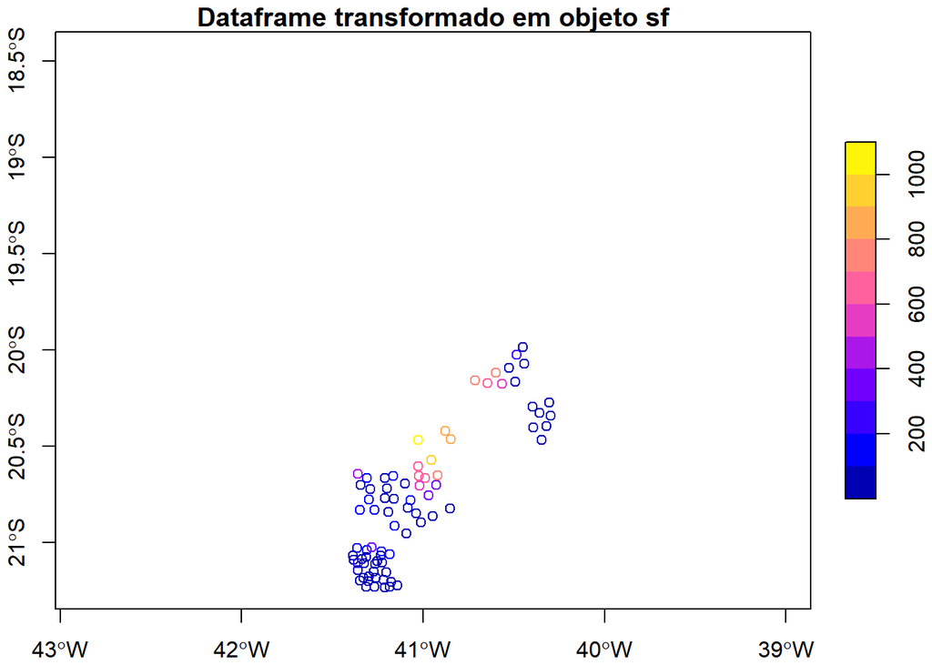

```r
plot(esper_sf["C1"],
     main = "Dataframe transformado em objeto sf",
     axes =T)
```

#### Exercício 07

Importar os mesmos dados mas indicando a geometria com as coordenadas projetadas (verifique as colunas e nomes correspondentes).

No caso inverso, passar um objeto “sf” para dataframe com coordenadas, usamos a função `sf::st_write()`. Para incluir as coordenadas na saída os argumentos são:

`st_write(dado_sf, "dado_novo.csv", layer_options = "GEOMETRY=AS_XY")`

A função `write_sf()` também grava, mas em forma “silenciosa”, ou seja não emite mensagem de gravação e sobre-escreve o arquivo se o nome já existe;

#### Exercício 08

A partir do objeto criado vamos salvar os registros num novo dataframe, preservando a geometria

```r
st_write(esper_sf,                       # dados a gravar
         "data/esper_novo.csv",        # novo arquivo com caminho de garavação
         layer_options = "GEOMETRY=AS_XY", # opção para salvar a geometria
         delete_dsn=TRUE)               # se o nome já existe, apague o arquivo primeiro
```

```
## Deleting source `C:\Users\Walter Pina\Documents\Github\Intro_analise_espacial_R\data\esper_novo.csv' using driver `CSV'
## Writing layer `esper_novo' to data source `C:\Users\Walter Pina\Documents\Github\Intro_analise_espacial_R\data\esper_novo.csv' using driver `CSV'
## options:        GEOMETRY=AS_XY
## features:       100
## fields:         11
## geometry type:  Point
```

```r
esper_novo <- read.csv("data/esper_novo.csv") # ler o arquivo gravado
head(esper_novo)
```

```
##          X        Y X.1      Proj Leitura      E       N C1    L2    L3
## 1 -40.3196 -20.3954   1 Esperanca     325 362305 7744205  4 -0.28  0.00
## 2 -40.3587 -20.3257   2 Esperanca     326 358155 7751897  2  0.00  0.00
## 3 -40.3053 -20.2712   3 Esperanca     327 363680 7757968  2  0.08  0.09
## 4 -40.3481 -20.4665   4 Esperanca     328 359388 7736321 20 -0.18  0.06
## 5 -40.2975 -20.3405   5 Esperanca     329 364564 7750307 12 -0.13 -0.07
## 6 -40.8515 -20.8231   6 Esperanca     330 307322 7696319 12 -0.60 -0.38
##     L4    L5    L6
## 1 0.28 -1.27  0.46
## 2 0.00  0.01  0.31
## 3 0.12 -2.12 -0.05
## 4 0.19 -1.66  0.65
## 5 0.15 -1.90  0.73
## 6 0.71 -0.34 -0.57
```

FIM da segunda parte

CREDITOS:

- Edzer Pebesma (2018). sf: Simple Features for R. R package version 0.6-3. https://CRAN.R-project.org/package=sf
- Robert J. Hijmans (2017). raster: Geographic Data Analysis and Modeling. R package version 2.6-7. https://CRAN.R-project.org/package=raster
- Hadley Wickham (2017). tidyverse: Easily Install and Load the ‘Tidyverse’. R package version 1.2.1. https://CRAN.R-project.org/package=tidyverse
- Fonte dos dados: o próprio autor do tutorial ou extraídos do portal IBGE: https://www.ibge.gov.br/